# Hypothesis Testing

# 7 Sample Size

We have already seen how increasing the sample size increases the power of the test. This should intuitively make sense as well, as a large sample means that you have collected more information, which makes it easier to correctly reject the null hypothesis when you should. To ensure that your sample size is big enough, you will need to conduct a power analysis calculation.

Using the `pingouin` package we can conduct power analysis where we can specify any three quantities and get the fourth one since these four quantities are dependent on each other:

- Sample Size
- Effect Size
- Significance level
- Power

Let’s use the previous exercise (Chi-square test to find the association between gender and education) as an example where the power of the test was low (power = 0.062). Let’s run the same power test to calculate how many people I need to survey if I wish to achieve 90% power when the significance level is still 0.01 and the effect size is 0.065 that we calculated using `pg.chi2_independence`.

```python
# Using pg.power_chi2() function because we want to calculate the sample size required,
# to achieve 90% power and w is the effect size as calculated previously
# the degrees of freedom is 6 and the significance level is 0.01

pg.power_chi2(dof=6, w=0.065, n=None, power=0.9, alpha=0.01)
```

```
## 5486.82335980266
```

We need to survey 5487 people to achieve 90% power when the significance level is 0.01. Always round estimates of required sample size up (even if the decimal place is below 0.5).

Usually, when conducting an experiment, we use conventional effect size. For example, how many students should we sample (to find the association between gender and education) to detect a medium effect, when power is 0.8, degrees of freedom is 6 and significance level is 0.01?

```python
# Choose any value between 0.2 and 0.6 as shown in the last exercise table
# the power of the test is 0.8 and the degrees of freedom is 6

pg.power_chi2(dof=6, w=0.5, n=None, power=0.8, alpha=0.01)
```

```
## 75.48740710075526
```

We need to survey 76 students to detect a medium effect. Now we will look at the conventional effect size of the correlation test.

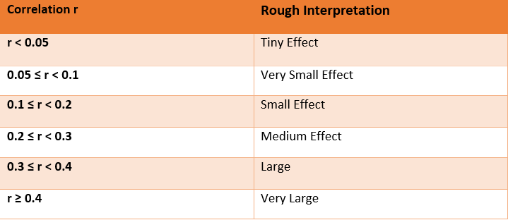

Suppose I want to conduct a one-sided correlation test to determine if there is a correlation between student’s absences and their final exam grades. I decide to carry out an experiment where I want to detect a large effect, with 90% power and 0.05 significance level. How many students do I need to carry out this experiment?

```python
# Choose any value between 0.3 and 0.4 as shown in table above
# the power of test is 0.9
# tail = 'one-sided' because we are conducting one sided test

pg.power_corr(r=0.35, n=None, power=0.9, alpha=0.05, tail='one-sided' )
```

```
## 66.1621080271319
```

Hence, we need 67 students to detect a large effect, with 90% power and 0.05 significance level.

Let’s use the example from `airqulity_data`. If we are interested in conducting a two-sample independent t-test to see if the average temperature in May is significantly different from the average temperature in July, how many observations do I need to achieve 80% power when the significance level is still 0.05 and the effect size is medium?

```python
# Use two-sample t-test (equal sample sizes) where medium cohen_d is between 0.5 to 0.8
# specify power which is 80% and the type since it is two-sample
# specify the alternative hypothesis which is two-sided in our case

pg.power_ttest(d=0.5, n=None, power=0.8, alpha=0.05,
               contrast='two-samples', tail='two-sided')
```

```
## 63.76561137745679
```

## 7.1 Exercise

### **Exercise**

1. Suppose I am conducting a one-way ANOVA which has 5 groups, I want to calculate the sample size in each group to obtain a power of 0.80 when the effect size is 0.25 and the significance level is 0.05.

(**Hint:** use `help(pg.power_anova)`)

2. Suppose I want to conduct a correlation test to determine if there is a correlation between the weight of a participant at the beginning of the fitness program and the participant’s weight change after 6 months. How many subjects do I need to sample to detect a small positive relationship with 90% power and 0.05 significance level?

(**Hint:** It is a one-sided test since we believe there is a small positive effect and a small effect is between 0.1 and 0.2).

### **Show Answer**

1. Suppose I am conducting a one-way ANOVA which has 5 groups, I want to calculate the sample size in each group to obtain a power of 0.80 when the effect size is 0.25 and the significance level is 0.05.

(**Hint:** use `help(pg.power_anova)`)

```python
# For a one-way ANOVA and use pwr.anova.test() function
# where k is number of groups and effect size is eta = 0.25

pg.power_anova(eta=0.25, k=5, n=None, power=0.8, alpha=0.05)
```

```
## 8.168120470963004
```

We need about 9 per group.

2. Suppose I want to conduct a correlation test to determine if there is a correlation between the weight of a participant at the beginning of the fitness program and the participant’s weight change after 6 months. How many subjects do I need to sample to detect a small positive relationship with 90% power and 0.05 significance level?

(**Hint:** It is a one-sided test since we believe there is a small positive effect and a small effect is between 0.1 and 0.2).

```python
# Choose any value between 0.1 and 0.2 as shown in table above
# power of test is 0.9
# the tail = 'one-sided' because we are conducting one sided test

pg.power_corr(r=0.125, n=None, power=0.9, alpha=0.05, tail='one-sided')
```

```
## 544.3484370516518
```

I need to observe about 545 participants.

# Summary

By now you should:

- Understand what Type I and Type II errors are.
- Know the relationship between alpha and Type I error and calculate the probability of Type I error.
- Know why effect size is required and calculate the effect size.
- Know the relationship between Beta and Type II error.
- Calculate the power of the test and calculate the probability of Type II error.
- Calculate the sample size given alpha, power and effect size.